# R Notebook for the Housepricing Comp

The Data explorer package is great for a first stab at unknown data. First things first;

- The dependent variable - the thing we want to predict - is continuous –> regression problem
  - GLM: Gamma with Log, Inverse or Identity link
  - Regression Tree
  - Random Forrest Reg Tree
- Not normally distributed –> important to match the algo to the distribution transformation
  - Gool ol’ OLS with a transformation?
- Loads of missing data to remedy
  - Which means we should add the test and train sets together - to save effort when scoring & validating

### Raw Combined Data File

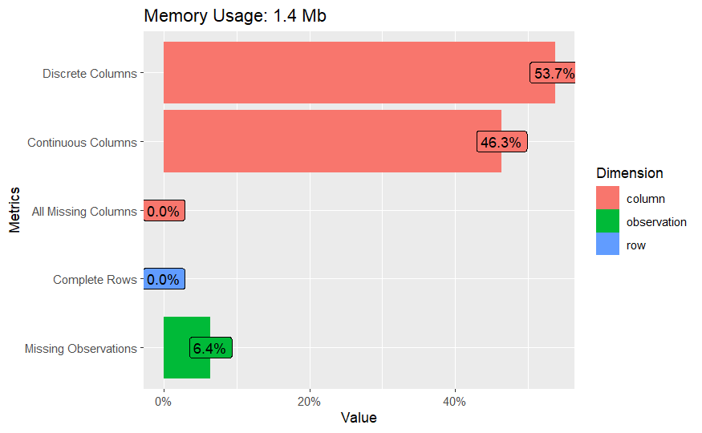

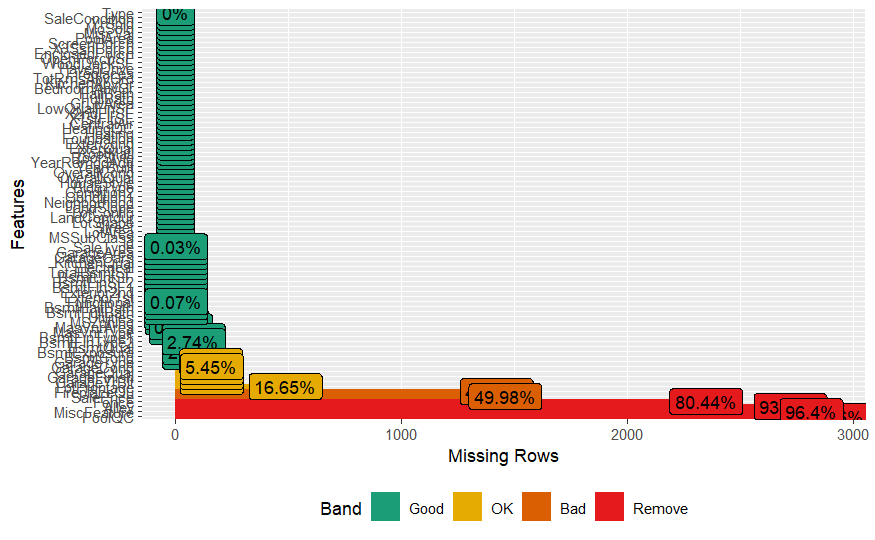

Start by filling in the missing data and running some correlation plots to understand the multicollinearity;

# Post Cleaned, Grouped and Filled data:

Factors with no variance such as Utilities have been dropped

Other insights include the basement variables - can it be used for rental income?

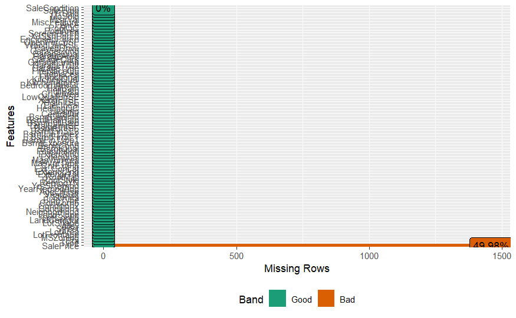

The new plots show we have a complete data set. (Only the dependent variable for the test set is missing)

The data is split back into the training and test set, to start modelling. The training set is split into a validation set too, to test over-fitting since we are parameterising

The correlation heatmap from the ExploratoryData package’s report is too dense to read properly. For a parameterised model multicollinearity is not good at all.We will split the dataset up into readable chunks and assess.

[figure not shown]

###Correlation

To reduce the data set to a more manageable set for the parameterised models, lets remove the variables that have no correlation with log of SalePrice. This is done by first looking at the numerical variables and removing any where the p-value for the correlation between the ln of SalesPrice and the numeric variable is not significant (p >= 0.05) by Spearman correlation

The remaining variables are mostly assessed for near-perfect multicolinearity.

[figure not shown]

The result is that we remove the following variables;

- YearBuilt
- YearRemodAdd
- Exterior1st
- Exterior2nd
- Condition 1
- Condition 2

### EOM

```
              (Intercept)                  EraOlder             MSZoningOther
           9.625189850576           -0.042825606595            0.381208192967
            MSZoningRL/RP                MSZoningFV                   LotArea
           0.400721430589            0.318602307531            0.000003713255
         LotConfigCulDSac       NeighborhoodEdwards       NeighborhoodBrkSide
           0.027280271466           -0.084162963922            0.029610854548
      NeighborhoodMitchel       NeighborhoodCrawfor       NeighborhoodVeenker
          -0.023016431085            0.245381045810            0.222081691516
      NeighborhoodSomerst       NeighborhoodStoneBr       NeighborhoodNoRidge
           0.173343031962            0.347223503943            0.271462976138
      NeighborhoodNridgHt           ConCombNor_2Nor           ConCombPos_3Pos
           0.297819332330            0.038575456343           -0.350307570030
            BldgTypeTwnhs            BldgTypeTwnhsE                  AgeOfHse
          -0.280876038956           -0.160965337378            0.000066859896
                YrsSRemod            RoofStyleGable             RoofMatlOther
          -0.003107074459           -0.078576185142            0.183331322332
Ext_ConcatCemntBd_Wd Sdng Ext_ConcatCemntBd_Wd Shng Ext_ConcatHdBoard_MetalSd
          -0.015568127693           -0.008872623133            0.007517541291
Ext_ConcatHdBoard_Plywood  Ext_ConcatStucco_Wd Shng            MasVnrTypeNone
          -0.021597430192           -0.029755267469           -0.042654664398
              ExterQualFa               ExterCondTA                BsmtQualTA
          -0.049166553172            0.018534725566           -0.012244496507
          BsmtFinType1LwQ           BsmtFinType1Rec           BsmtFinType2Rec
           0.026151748335            0.033867263042           -0.039218118078
   BsmtGenInfoSelfConRecS               CentralAirY              HeatingOther
           0.051555233538            0.135967065813            0.005751431306
              HeatingQCGd                  FullBath                  HalfBath
          -0.012801640069            0.193408434950            0.096187419097
             KitchenAbvGr           FireplaceQuNone         GarageTypeBuiltIn
          -0.058776067914           -0.111567148567           -0.016980411974
        GarageTypeCarPort               GarageYrBlt           GarageFinishRFn
          -0.186998584650            0.000902239865           -0.011584179072
             GarageQualGd              GarageQualPo              GarageCondFa
           0.065407878096           -0.140372944470           -0.150903695445
             GarageCondTA               PavedDriveP               OpenPorchSF
          -0.049876586692           -0.000253603133            0.000385198672
                FenceGdWo                FenceMnPrv           MiscFeatureOthr
          -0.065988934971           -0.022509865754           -0.209252961892
              SaleTypeGWD               SaleTypeNew      SaleConditionPartial
          -0.037587443713           -0.059003062063            0.108552885019
Ext_ConcatAsbShng_Wd Sdng Ext_ConcatBrkFace_MetalSd Ext_ConcatMetalSd_VinylSd
           0.000000000000            0.000000000000            0.000000000000
   Ext_ConcatOther_Stucco   Ext_ConcatOther_VinylSd Ext_ConcatPlywood_VinylSd
           0.000000000000            0.000000000000            0.000000000000
      BsmtGenInfoRentBsmt            GarageQualNone
           0.141918875916           -0.308937847887
```

After that we will do some feature engineering to see if there is an improvement

These are unused codes